# 12_reshuffle_two_mean

## 12_reshuffle_two_mean

#### Question

1. *S-IC.B.5: Use data from a randomized experiment to compare two treatments; use simulations to decide if differences between parameters are significant.*

   Dante and Yara wonder if they are equally skilled at archery. They decide to compare this year’s scores using a two-tail [approximate permutation test](https://en.wikipedia.org/wiki/Permutation_test), using a significance level of 5%.

   | Dante | Yara |
   | --- | --- |
   | 224 | 200 |
   | 236 | 216 |
   | 235 | 245 |
   | 230 | 223 |
   | 236 | 207 |
   | 216 | 192 |
   | 210 | 204 |
   | 237 | 208 |
   | 239 |  |
   | 234 |  |
   | 226 |  |
   | 232 |  |

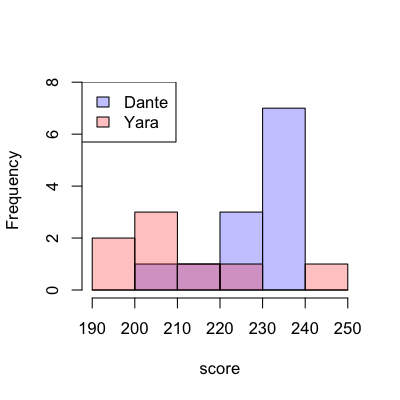

   To run the test, first calculate the observed absolute difference of sample means.
   - Dante’s sample mean = $\bar{x}_1 =$
   - Yara’s sample mean = $\bar{x}_2 =$
   - The absolute difference = $|\bar{x}_2 - \bar{x}_1| =$

## Permutation Test

   1. Reshuffle those two samples 1000 times. I’d recommend [this tool](https://chadworley.github.io/a2/tools/two_list_reshuffler.html), which wants comma-separated data, so here are the samples in that format:

      224, 236, 235, 230, 236, 216, 210, 237, 239, 234, 226, 232

      200, 216, 245, 223, 207, 192, 204, 208

      Notice this reshuffling is equivalent to putting all the scores on cards, shuffling them all together, and then dealing into two piles (repeated 1000 times). Notice, Dante had 12 scores, so one pile always gets 12 numbers, and the other pile gets 8 numbers. We are simulating the hypothesis that maybe both people’s sample came from equivalent populations with a difference of sample means from natural variation, not unequal skill. We will then see if the observed difference is copacetic with the simulated differences.
   2. Paste the 1000 rows into a spreadsheet.
   3. For each row, find the absolute difference of the means. Remember, spreadsheets have `=ABS()` for absolute value and `=AVERAGE()` to find a mean.
   4. How many times was the simulation’s absolute difference of means smaller than the observed absolute difference of means. (Choose an interval.)
   5. How many times was the simulation’s difference as big or bigger than the observation’s difference? (Choose an interval.)
   6. What **proportion** of the time was the simulation as big or bigger? (In statistics this is called the $p$-value.) (Choose an interval.)
   7. If the $p$-value is less than 0.05, then the difference is significant. Otherwise, the difference is not significant. Is the difference significant?
   8. So, then, can we conclude that Dante is significantly better than Yara at archery?

#### Question

2. *S-IC.B.5: Use data from a randomized experiment to compare two treatments; use simulations to decide if differences between parameters are significant.*

   Ilaria and Rhea wonder if they are equally skilled at archery. They decide to compare this year’s scores using a two-tail [approximate permutation test](https://en.wikipedia.org/wiki/Permutation_test), using a significance level of 5%.

   | Ilaria | Rhea |
   | --- | --- |
   | 236 | 209 |
   | 222 | 203 |
   | 208 | 226 |
   | 232 | 218 |
   | 251 | 218 |
   | 209 | 216 |
   | 241 | 185 |
   | 245 | 201 |
   | 215 |  |

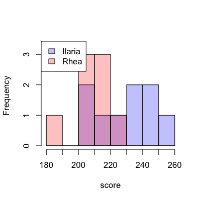

   To run the test, first calculate the observed absolute difference of sample means.
   - Ilaria’s sample mean = $\bar{x}_1 =$
   - Rhea’s sample mean = $\bar{x}_2 =$
   - The absolute difference = $|\bar{x}_2 - \bar{x}_1| =$

## Permutation Test

   1. Reshuffle those two samples 1000 times. I’d recommend [this tool](https://chadworley.github.io/a2/tools/two_list_reshuffler.html), which wants comma-separated data, so here are the samples in that format:

      236, 222, 208, 232, 251, 209, 241, 245, 215

      209, 203, 226, 218, 218, 216, 185, 201

      Notice this reshuffling is equivalent to putting all the scores on cards, shuffling them all together, and then dealing into two piles (repeated 1000 times). Notice, Ilaria had 9 scores, so one pile always gets 9 numbers, and the other pile gets 8 numbers. We are simulating the hypothesis that maybe both people’s sample came from equivalent populations with a difference of sample means from natural variation, not unequal skill. We will then see if the observed difference is copacetic with the simulated differences.
   2. Paste the 1000 rows into a spreadsheet.
   3. For each row, find the absolute difference of the means. Remember, spreadsheets have `=ABS()` for absolute value and `=AVERAGE()` to find a mean.
   4. How many times was the simulation’s absolute difference of means smaller than the observed absolute difference of means. (Choose an interval.)
   5. How many times was the simulation’s difference as big or bigger than the observation’s difference? (Choose an interval.)
   6. What **proportion** of the time was the simulation as big or bigger? (In statistics this is called the $p$-value.) (Choose an interval.)
   7. If the $p$-value is less than 0.05, then the difference is significant. Otherwise, the difference is not significant. Is the difference significant?
   8. So, then, can we conclude that Ilaria is significantly better than Rhea at archery?

#### Question

3. *S-IC.B.5: Use data from a randomized experiment to compare two treatments; use simulations to decide if differences between parameters are significant.*

   Mila and Talia wonder if they are equally skilled at archery. They decide to compare this year’s scores using a two-tail [approximate permutation test](https://en.wikipedia.org/wiki/Permutation_test), using a significance level of 5%.

   | Mila | Talia |
   | --- | --- |
   | 200 | 252 |
   | 199 | 223 |
   | 200 | 248 |
   | 205 | 223 |
   | 182 | 229 |
   | 264 | 216 |
   | 161 | 255 |
   | 210 | 238 |
   | 245 |  |
   | 157 |  |

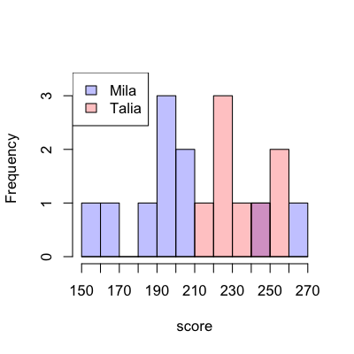

   To run the test, first calculate the observed absolute difference of sample means.
   - Mila’s sample mean = $\bar{x}_1 =$
   - Talia’s sample mean = $\bar{x}_2 =$
   - The absolute difference = $|\bar{x}_2 - \bar{x}_1| =$

## Permutation Test

   1. Reshuffle those two samples 1000 times. I’d recommend [this tool](https://chadworley.github.io/a2/tools/two_list_reshuffler.html), which wants comma-separated data, so here are the samples in that format:

      200, 199, 200, 205, 182, 264, 161, 210, 245, 157

      252, 223, 248, 223, 229, 216, 255, 238

      Notice this reshuffling is equivalent to putting all the scores on cards, shuffling them all together, and then dealing into two piles (repeated 1000 times). Notice, Mila had 10 scores, so one pile always gets 10 numbers, and the other pile gets 8 numbers. We are simulating the hypothesis that maybe both people’s sample came from equivalent populations with a difference of sample means from natural variation, not unequal skill. We will then see if the observed difference is copacetic with the simulated differences.
   2. Paste the 1000 rows into a spreadsheet.
   3. For each row, find the absolute difference of the means. Remember, spreadsheets have `=ABS()` for absolute value and `=AVERAGE()` to find a mean.
   4. How many times was the simulation’s absolute difference of means smaller than the observed absolute difference of means. (Choose an interval.)
   5. How many times was the simulation’s difference as big or bigger than the observation’s difference? (Choose an interval.)
   6. What **proportion** of the time was the simulation as big or bigger? (In statistics this is called the $p$-value.) (Choose an interval.)
   7. If the $p$-value is less than 0.05, then the difference is significant. Otherwise, the difference is not significant. Is the difference significant?
   8. So, then, can we conclude that Talia is significantly better than Mila at archery?

#### Question

4. *S-IC.B.5: Use data from a randomized experiment to compare two treatments; use simulations to decide if differences between parameters are significant.*

   Talia and Xena wonder if they are equally skilled at archery. They decide to compare this year’s scores using a two-tail [approximate permutation test](https://en.wikipedia.org/wiki/Permutation_test), using a significance level of 5%.

   | Talia | Xena |
   | --- | --- |
   | 199 | 251 |
   | 154 | 220 |
   | 142 | 258 |
   | 213 | 260 |
   | 229 | 221 |
   | 237 | 193 |
   | 191 | 249 |
   | 204 | 199 |
   | 176 | 256 |
   |  | 234 |
   |  | 209 |
   |  | 202 |

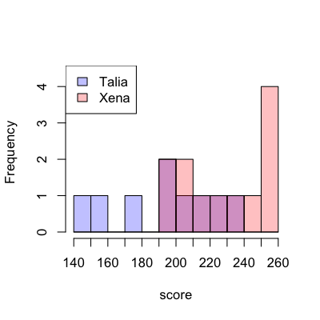

   To run the test, first calculate the observed absolute difference of sample means.
   - Talia’s sample mean = $\bar{x}_1 =$
   - Xena’s sample mean = $\bar{x}_2 =$
   - The absolute difference = $|\bar{x}_2 - \bar{x}_1| =$

## Permutation Test

   1. Reshuffle those two samples 1000 times. I’d recommend [this tool](https://chadworley.github.io/a2/tools/two_list_reshuffler.html), which wants comma-separated data, so here are the samples in that format:

      199, 154, 142, 213, 229, 237, 191, 204, 176

      251, 220, 258, 260, 221, 193, 249, 199, 256, 234, 209, 202

      Notice this reshuffling is equivalent to putting all the scores on cards, shuffling them all together, and then dealing into two piles (repeated 1000 times). Notice, Talia had 9 scores, so one pile always gets 9 numbers, and the other pile gets 12 numbers. We are simulating the hypothesis that maybe both people’s sample came from equivalent populations with a difference of sample means from natural variation, not unequal skill. We will then see if the observed difference is copacetic with the simulated differences.
   2. Paste the 1000 rows into a spreadsheet.
   3. For each row, find the absolute difference of the means. Remember, spreadsheets have `=ABS()` for absolute value and `=AVERAGE()` to find a mean.
   4. How many times was the simulation’s absolute difference of means smaller than the observed absolute difference of means. (Choose an interval.)
   5. How many times was the simulation’s difference as big or bigger than the observation’s difference? (Choose an interval.)
   6. What **proportion** of the time was the simulation as big or bigger? (In statistics this is called the $p$-value.) (Choose an interval.)
   7. If the $p$-value is less than 0.05, then the difference is significant. Otherwise, the difference is not significant. Is the difference significant?
   8. So, then, can we conclude that Xena is significantly better than Talia at archery?

#### Question

5. *S-IC.B.5: Use data from a randomized experiment to compare two treatments; use simulations to decide if differences between parameters are significant.*

   Dante and Ginevra wonder if they are equally skilled at archery. They decide to compare this year’s scores using a two-tail [approximate permutation test](https://en.wikipedia.org/wiki/Permutation_test), using a significance level of 5%.

   | Dante | Ginevra |
   | --- | --- |
   | 206 | 225 |
   | 237 | 228 |
   | 231 | 209 |
   | 206 | 218 |
   | 188 | 226 |
   | 223 | 234 |
   |  | 235 |
   |  | 224 |
   |  | 246 |

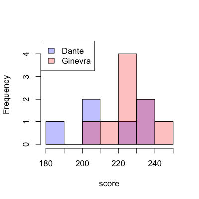

   To run the test, first calculate the observed absolute difference of sample means.
   - Dante’s sample mean = $\bar{x}_1 =$
   - Ginevra’s sample mean = $\bar{x}_2 =$
   - The absolute difference = $|\bar{x}_2 - \bar{x}_1| =$

## Permutation Test

   1. Reshuffle those two samples 1000 times. I’d recommend [this tool](https://chadworley.github.io/a2/tools/two_list_reshuffler.html), which wants comma-separated data, so here are the samples in that format:

      206, 237, 231, 206, 188, 223

      225, 228, 209, 218, 226, 234, 235, 224, 246

      Notice this reshuffling is equivalent to putting all the scores on cards, shuffling them all together, and then dealing into two piles (repeated 1000 times). Notice, Dante had 6 scores, so one pile always gets 6 numbers, and the other pile gets 9 numbers. We are simulating the hypothesis that maybe both people’s sample came from equivalent populations with a difference of sample means from natural variation, not unequal skill. We will then see if the observed difference is copacetic with the simulated differences.
   2. Paste the 1000 rows into a spreadsheet.
   3. For each row, find the absolute difference of the means. Remember, spreadsheets have `=ABS()` for absolute value and `=AVERAGE()` to find a mean.
   4. How many times was the simulation’s absolute difference of means smaller than the observed absolute difference of means. (Choose an interval.)
   5. How many times was the simulation’s difference as big or bigger than the observation’s difference? (Choose an interval.)
   6. What **proportion** of the time was the simulation as big or bigger? (In statistics this is called the $p$-value.) (Choose an interval.)
   7. If the $p$-value is less than 0.05, then the difference is significant. Otherwise, the difference is not significant. Is the difference significant?
   8. So, then, can we conclude that Ginevra is significantly better than Dante at archery?